# Makeover Monday 2020w2 Exploration

Billy Caughey

May 30, 2020

## Introduction

This is my week 2 submission for the Makeover Monday experiment. I am really excited about this problem because there is a lot of set theory going on. There will be some matrix algebra going on and I’m looking to use a Venn diagram. Not sure how I am going to do it yet, but it will happen!

## Purpose

For this week 2, we are considering the pesticides approved into the United States but not into other countries. Specifically, the other regions we are considering are EU, Brazil, and China. The visual for this week is below in figure 1.

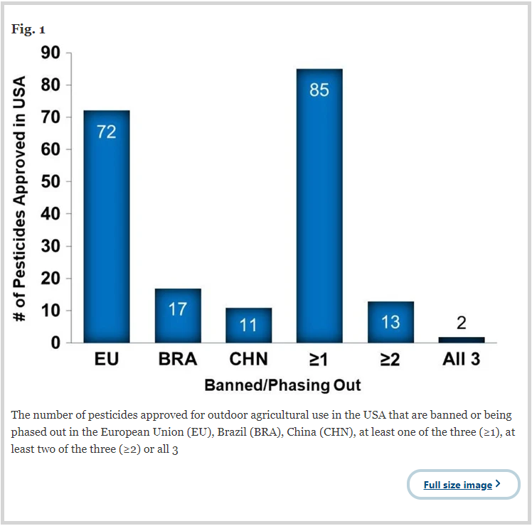

Fig. 1: Makeover Monday W2 Viz

Brazil and China having such a small number of banned pesticides is natural. The United States imports a lot of food from both these countries. That means it would be in the United States’s interest to align on pesticides.

What I would like to know, is the number of pesticides shared between countries and the United States. This will require some matrix algebra and a Venn diagram. In this situation, a Venn diagram will probably look just as nice as this bar chart.

##### Bring in the data

For this analysis, I will bring in the data only to show how to read the data in. With that said, chances are a new data set will need to be established from the results of the matrix algebra.

```r
library(httr)
library(readxl)
url <- "https://query.data.world/s/h2y64h7jm7wgvux5hwyumkbnrhvuop"
invisible(capture.output(GET(url, write_disk(tf <- tempfile(fileext = ".xlsx")))))
df <- read_excel(tf)
print(df)
```

```
FALSE # A tibble: 8 x 3
FALSE   Category                        `Lbs. Pesticides Used in USA Agr… `% of Total`
FALSE   <chr>                                                       <dbl>        <dbl>
FALSE 1 Total                                                  1200587514        100
FALSE 2 Banned in EU                                            322597233         26.9
FALSE 3 Banned in CHN                                            40014277          3.3
FALSE 4 Banned in BRA                                            25843457          2.2
FALSE 5 Banned in at Least 1                                    327817174         27.3
FALSE 6 Banned in at Least 2                                     45960605          3.8
FALSE 7 Banned in All 3                                          14677188          1.2
FALSE 8 Banned, Not Approved or Unknow…                         133711048         11.1
```

So, with the data in, I want to build some sort of Venn diagram. The data and the graph do not align. The data shows the probabilities of each country to the United States. These figures lend themselves to a Venn diagram nicely. For review, a Venn diagram is shown in figure 2.

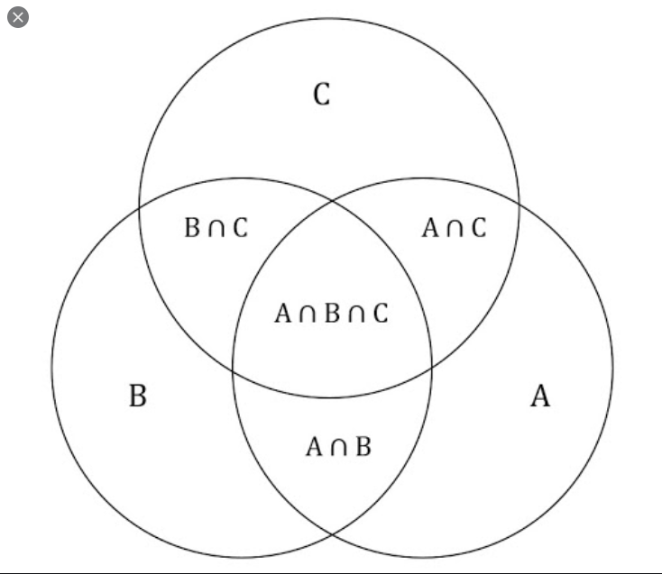

Fig. 2: Basic venn Diagram

Unfortunately, the math for this project does not workout. I invite the reader to workout the probability statements. (Hint: There is a linear combination)

I’m pretty sold on building out a Venn diagram, so I need to go back to the base data. With a little reading in the [original article](https://ehjournal.biomedcentral.com/articles/10.1186/s12940-019-0488-0), the supplement data files are provided. For this study, I will be calling in sheets S131 (EU), S132 (China), and S133 (Brazil) from additional file 5. These sheets show the pesticides banned or being phased out in each country that are still active in the United States. Additionally, the pounds used in 2016 are provided. This will provide more information to buildout the Venn diagram.

```r
library(readxl)

dat_eu <- read_xlsx(path = "12940_2019_488_MOESM5_ESM.xlsx",
                    sheet = "S131",
                    skip = 3,
                    col_names = c("Pesticide","Lbs","Percent"))

dat_ch <- read_xlsx(path = "12940_2019_488_MOESM5_ESM.xlsx",
                    sheet = "S132",
                    skip = 3,
                    col_names = c("Pesticide","Lbs","Percent"))

dat_br <- read_xlsx(path = "12940_2019_488_MOESM5_ESM.xlsx",
                    sheet = "S133",
                    skip = 3,
                    col_names = c("Pesticide","Lbs","Percent"))
```

```r
library(VennDiagram)

venn.diagram(x = list(dat_eu$Pesticide, dat_ch$Pesticide, dat_br$Pesticide),
             category.names = c("EU","CH","BR"),
             output = FALSE,
             filename = NULL,
             na = "remove")
```

[output not shown]